# Fancy axis plots!

## First, we need to get the proper libraries, many of which are dev versions from github:

```r
#install.packages('devtools')
#library(devtools)
#install_github("clauswilke/ggjoy")
#install_github("wilkelab/cowplot")
#install.packages('ggstance')

library(ggplot2)
library(ggstance)
library(ggjoy)
library(cowplot)
```

With that done, lets try some examples:

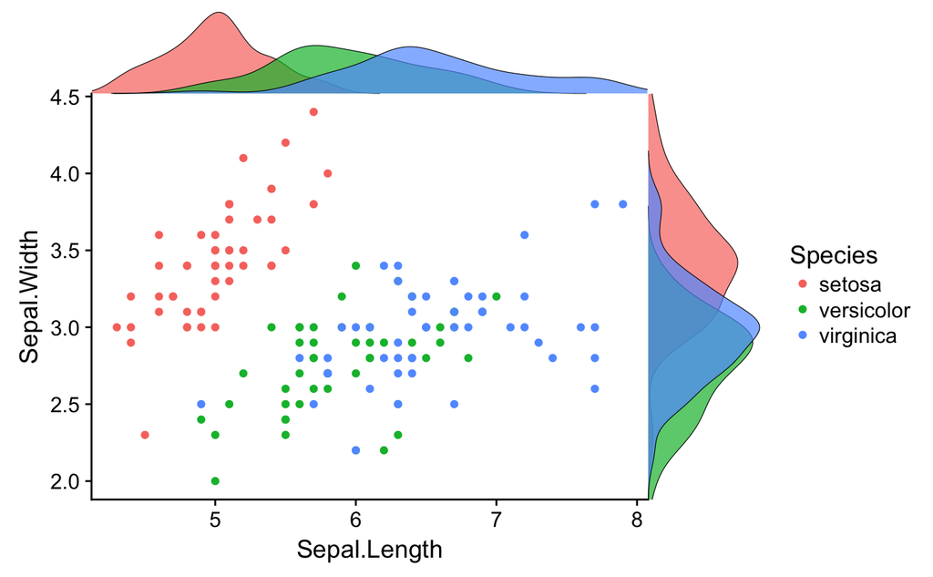

Neat! Lets unpack this a bit more:

We are starting with a basic ggplot-based scatter plot on the `iris` dataset. This is defined as `pmain`

```r
pmain = ggplot(iris,aes(x=Sepal.Length,y=Sepal.Width, color=Species)) + geom_point()
```

From here, we are using the `axis_canvas` function from `cowplot`. This takes an existing ggplot2 plot and creates a new plot for the axis. It allows for custom ‘axis-like’ objects or annotations in the margins. Check the help for details on this.

We also are using the `geom_ridgeline` and `geom_vridgeline` functions from `ggjoy`. These per the description:

‘Plots the sum of the y and height aesthetics versus x, filling the area between y and y + height with a color’

So we are gathering the datapoints present at every x value and creating a density plot. Reverse the concept for vridgeline.

```r
ggdraw(xdens)
```

[output not shown]